# Analyzing HTEs in the International Stroke Trial with the RATE

# Model Training

We train a Causal Survival Forest to estimate the CATE directly.

```r
# Training a Causal Survival Forest model on "train" set
train.model.CF <- grf::causal_forest(
  X = X.train.mat,
  Y = Y.train,
  W = W.train,
  # Use prop. treated individuals as W.hat = E[W | X_i] for everyone (RCT)
  W.hat = rep(mean(W.train), length(W.train)),
  honesty = TRUE,
  tune.parameters = "all",
  seed = SEED
)

# Generating predictions of the CSF model on "test" set
priorities.on.test$CF <- predict(train.model.CF, newdata=X.test.mat)$predictions
```

We evaluate the quality of fit for our Causal Forest in terms of calibration

```r
grf::test_calibration(train.model.CF)
```

```
##
## Best linear fit using forest predictions (on held-out data)
## as well as the mean forest prediction as regressors, along
## with one-sided heteroskedasticity-robust (HC3) SEs:
##
##                                Estimate Std. Error t value Pr(>t)
## mean.forest.prediction          0.99498    0.78676  1.2646 0.1030
## differential.forest.prediction  0.24763    0.28548  0.8674 0.1929
```

Next, we train a T-Learner with logistic regression base models, following “Counterfactual clinical prediction models could help to infer individualized treatment effects in randomized controlled trials” by Nguyen et al (2020): https://doi.org/10.1016/j.jclinepi.2020.05.022

```r
# Code adapted from https://doi.org/10.1016/j.jclinepi.2020.05.022 for
# purposes of direct comparison
train.model.TLearner.treated <- glm(
  outcome ~
    rcs(AGE, 3) + rcs(RSBP, 3) +  # Restricted cubic splines with 3 knots
    RDELAY + SEX + RCONSC + RCT + RVISINF +
    STYPE + RDEF1 + RDEF2 + RDEF3 + RDEF4 + RDEF5 + RDEF6 + RDEF7 + RDEF8 +
    RATRIAL + RASP3 + REGION,
  # Train on just the treated units
  data = cbind(outcome=Y.train[W.train == 1], train.df[W.train == 1,]),
  family="binomial"  # Binary outcomes -> Logistic regression
)

train.model.TLearner.controls <- glm(
  outcome ~
    rcs(AGE, 3) + rcs(RSBP, 3) +
    RDELAY + SEX + RCONSC + RCT + RVISINF +
    STYPE + RDEF1 + RDEF2 + RDEF3 + RDEF4 + RDEF5 + RDEF6 + RDEF7 + RDEF8 +
    RATRIAL + RASP3 + REGION,
  data = cbind(outcome=Y.train[W.train == 0], train.df[W.train == 0,]),
  family="binomial"
)

# Estimate Y(1) for every subject in the test set
test.preds.1 <- predict(train.model.TLearner.treated, test.df, "response")

# Estimate Y(0) for every subject in the test set
test.preds.0 <- predict(train.model.TLearner.controls, test.df, "response")

# Estimate Y(1) - Y(0) for every subject in the test set
priorities.on.test$GLMTLearner <- test.preds.1 - test.preds.0
```

We evaluate the fit of the T-Learner by examining the discrimination and calibration of the base models. Both appear to be well-calibrated with good discrimination.

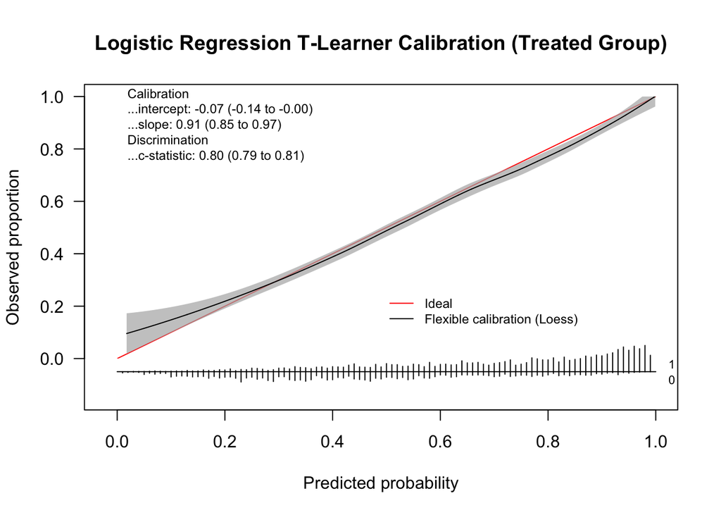

```
## Call:
## CalibrationCurves::val.prob.ci.2(p = test.preds.1[W.test == 1],
##     y = Y.test[W.test == 1], main = "Logistic Regression T-Learner Calibration (Treated Group)")
##
## A 95% confidence interval is given for the calibration intercept, calibration slope and c-statistic.
##
##           Dxy       C (ROC)            R2             D      D:Chi-sq
##  6.023025e-01  8.011512e-01  3.411370e-01  2.896794e-01  1.367707e+03
##           D:p             U      U:Chi-sq           U:p             Q
##  0.000000e+00  2.359739e-03  1.313325e+01  1.406537e-03  2.873196e-01
##         Brier     Intercept         Slope          Emax  Brier scaled
##  1.766022e-01 -7.361300e-02  9.074660e-01  2.860025e-02  2.582384e-01
##          Eavg           ECI
##  1.668941e-02  3.844527e-02
```

```r
CalibrationCurves::val.prob.ci.2(
  test.preds.1[W.test == 1],
  Y.test[W.test == 1],
  main="Logistic Regression T-Learner Calibration (Treated Group)"
)
```

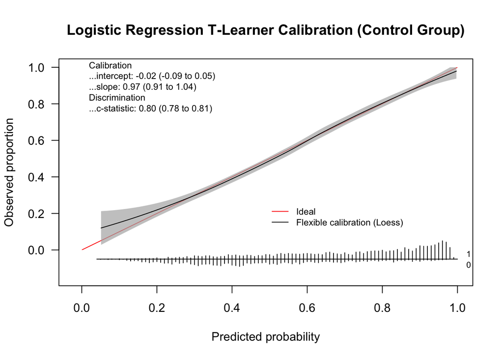

```
## Call:
## CalibrationCurves::val.prob.ci.2(p = test.preds.0[W.test == 0],
##     y = Y.test[W.test == 0], main = "Logistic Regression T-Learner Calibration (Control Group)")
##
## A 95% confidence interval is given for the calibration intercept, calibration slope and c-statistic.
##
##           Dxy       C (ROC)            R2             D      D:Chi-sq
##  5.905539e-01  7.952770e-01  3.223690e-01  2.691247e-01  1.282572e+03
##           D:p             U      U:Chi-sq           U:p             Q
##  0.000000e+00 -1.991957e-04  1.051430e+00  5.911326e-01  2.693239e-01
##         Brier     Intercept         Slope          Emax  Brier scaled
##  1.758244e-01 -1.727829e-02  9.701193e-01  7.852422e-03  2.460756e-01
##          Eavg           ECI
##  7.848531e-03  1.022711e-02
```

```r
CalibrationCurves::val.prob.ci.2(
  test.preds.0[W.test == 0],
  Y.test[W.test == 0],
  main="Logistic Regression T-Learner Calibration (Control Group)"
)
```

To enable direct comparison with the approach employed by [Kent et al. 2016](https://doi.org/10.1093/ije/dyw118) we also train a linear (logistic) regression model to predict the outcome, independent of treatment.

```r
train.model.linear.risk <- glm(
  outcome ~
    rcs(AGE, 3) + rcs(RSBP, 3) +
    RDELAY + SEX + RCONSC + RCT + RVISINF +
    STYPE + RDEF1 + RDEF2 + RDEF3 + RDEF4 + RDEF5 + RDEF6 + RDEF7 + RDEF8 +
    RATRIAL + RASP3 + REGION,
  data = cbind(outcome=Y.train, train.df),
  family="binomial"
)

# Estimate Y for every subject in the test set, irrespective of treatment
priorities.on.test$LRRisk <- predict(train.model.linear.risk, test.df, "response")
```

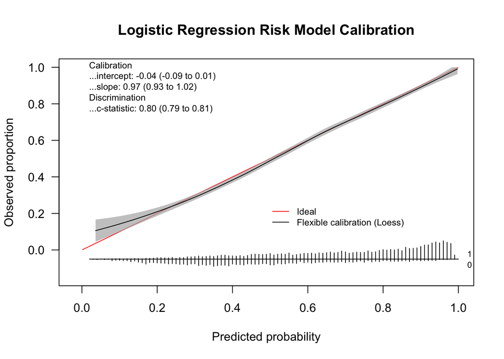

```
## Call:
## CalibrationCurves::val.prob.ci.2(p = priorities.on.test$LRRisk,
##     y = Y.test, main = "Logistic Regression Risk Model Calibration")
##
## A 95% confidence interval is given for the calibration intercept, calibration slope and c-statistic.
##
##           Dxy       C (ROC)            R2             D      D:Chi-sq
##  6.028339e-01  8.014170e-01  3.375928e-01  2.851682e-01  2.704394e+03
##           D:p             U      U:Chi-sq           U:p             Q
##  0.000000e+00  2.589655e-04  4.454993e+00  1.077980e-01  2.849092e-01
##         Brier     Intercept         Slope          Emax  Brier scaled
##  1.748329e-01 -4.261176e-02  9.717405e-01  1.221465e-02  2.583700e-01
##          Eavg           ECI
##  8.836785e-03  1.228445e-02
```

```r
CalibrationCurves::val.prob.ci.2(
  priorities.on.test$LRRisk,
  Y.test,
  main="Logistic Regression Risk Model Calibration"
)
```

Next we train a random forest to estimate risk, trained just on those individuals who were *not* assigned aspirin at randomization. Note the difference in approach relative to [Kent et al. 2016](https://doi.org/10.1093/ije/dyw118).

```r
# Training a Random Survival Forest model on "train" set
train.model.RF.controls <- grf::regression_forest(
  X = X.train.mat[W.train == 0,],
  Y = Y.train[W.train == 0],
  tune.parameters = "all",
  seed = SEED
)

# Generating predictions of the RF train model on test
priorities.on.test$RFRisk <- predict(
  train.model.RF.controls,
  newdata=X.test.mat)$predictions
```

Evaluate quality of fit for random forest model in terms of calibration, AUROC

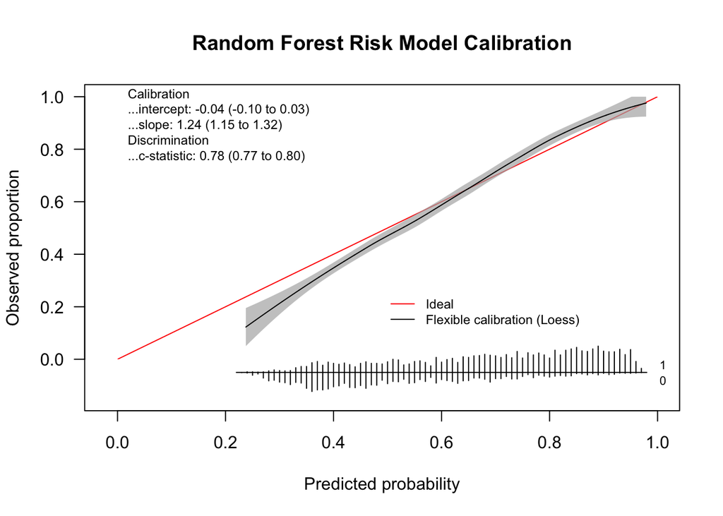

```
## Call:
## CalibrationCurves::val.prob.ci.2(p = priorities.on.test$RFRisk[W.test ==
##     0], y = Y.test[W.test == 0], main = "Random Forest Risk Model Calibration")
##
## A 95% confidence interval is given for the calibration intercept, calibration slope and c-statistic.
##
##           Dxy       C (ROC)            R2             D      D:Chi-sq
##  5.698340e-01  7.849170e-01  3.003326e-01  2.482159e-01  1.183004e+03
##           D:p             U      U:Chi-sq           U:p             Q
##  0.000000e+00  6.647322e-03  3.365455e+01  4.920490e-08  2.415686e-01
##         Brier     Intercept         Slope          Emax  Brier scaled
##  1.812625e-01 -3.825829e-02  1.236012e+00  6.635995e-02  2.227575e-01
##          Eavg           ECI
##  3.151399e-02  1.423874e-01
```

```r
CalibrationCurves::val.prob.ci.2(
  priorities.on.test$RFRisk[W.test == 0],
  Y.test[W.test == 0],
  # priorities.on.test$RFRisk,
  # Y.test,
  main="Random Forest Risk Model Calibration"
)
```

# Model Evaluation

## Estimating Doubly Robust Scores on the Test Set

First we fit a Causal Forest with honest fitting to the test set (in order to generate our doubly robust scores).

```r
eval.model.CF <- grf::causal_forest(
  X = X.test.mat,
  Y = Y.test,
  W = W.test,
  W.hat = rep(mean(W.test), length(W.test)),
  honesty = TRUE,
  tune.parameters = "all",
  seed = SEED
)
```

Then we calculate AIPW scores using the evaluation forest

```r
# Compute ATE from AIPW
tau.hat <- predict(eval.model.CF)$predictions
e.hat <- eval.model.CF$W.hat # P[W=1|X]
m.hat <- eval.model.CF$Y.hat # E[Y|X]
mu.hat.0 <- m.hat - e.hat * tau.hat        # E[Y|X,W=0] = E[Y|X]-e(X)*tau(X)
mu.hat.1 <- m.hat + (1 - e.hat) * tau.hat  # E[Y|X,W=1] = E[Y|X]+(1-e(X))*tau(X)
aipw.scores <- (tau.hat +
                  W.test / e.hat * (Y.test -  mu.hat.1) -
                  (1 - W.test) / (1 - e.hat) * (Y.test -  mu.hat.0))

# Note that we could equivalently just call grf::get_scores,
# but we show calculations above for didactic transparency
# sum(aipw.scores != grf::get_scores(eval.model.CF))  # Should equal 0
```

## Rank-Weighted Average Treatment Effect (RATE)

Finally, we evaluate how well our Random Forest, T-Learner,and Causal Forest perform in terms of the RATE (i.e., how well do the stratify the “test” set by estimated treatment effect)

```r
# A wrapper function for calculating the RATE + plotting the TOC curve
# NOTE: This is non-deterministic; set seed beforehand for reproducibility
analyze.RATE <- function(eval.model, priorities, title.str, target="AUTOC") {
  rate.obj <- grf::rank_average_treatment_effect(
    forest = eval.model,  # The evaluation set forest
    target = target,  # Type of RATE estimate/weighting function ("QINI" vs. "AUTOC")
    priorities = priorities,  # Treatment prioritization scores S(X_i)
    q = seq(0.005, 1, by = 0.005),  # The grid to compute TOC on (granularity)
    R = 1000  # Number of bootstrap replicates for the SEs
  )
  plot.title <- sprintf(
      title.str,
      rate.obj$estimate,  # RATE estimate
      rate.obj$estimate - qnorm(0.975) * rate.obj$std.err,  # 95% CI lower bound
      rate.obj$estimate + qnorm(0.975) * rate.obj$std.err,  # 95T CI upper bound
      2 * pnorm(-abs(rate.obj$estimate)/rate.obj$std.err)  # P-value (2-sided)
  )
  plot(rate.obj, main=plot.title)  # Plot the TOC curve
}
```

RATE of the Random Forest Risk model

```r
set.seed(SEED)
analyze.RATE(
  eval.model = eval.model.CF,
  priorities = priorities.on.test$RFRisk,
  title.str = "TOC - Random Forest Risk\nRATE = %.4f (%.4f, %.4f), P = %.3f",
  target = "AUTOC"
)
```

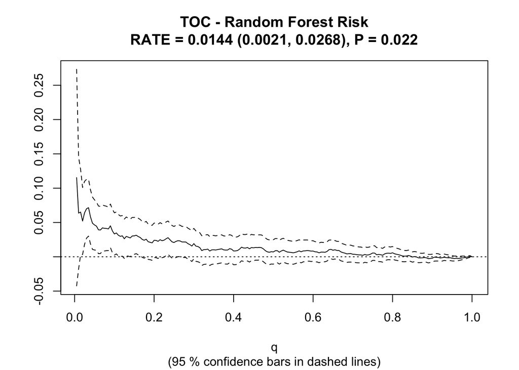

RATE of the Logistic Regression Risk model (following [Kent et al. 2016](https://doi.org/10.1093/ije/dyw118)).

```r
set.seed(SEED)
analyze.RATE(
  eval.model = eval.model.CF,
  priorities = priorities.on.test$LRRisk,
  title.str = "TOC - Logistic Regression Risk\nRATE = %.4f (%.4f, %.4f), P = %.3f",
  target = "AUTOC"
)
```

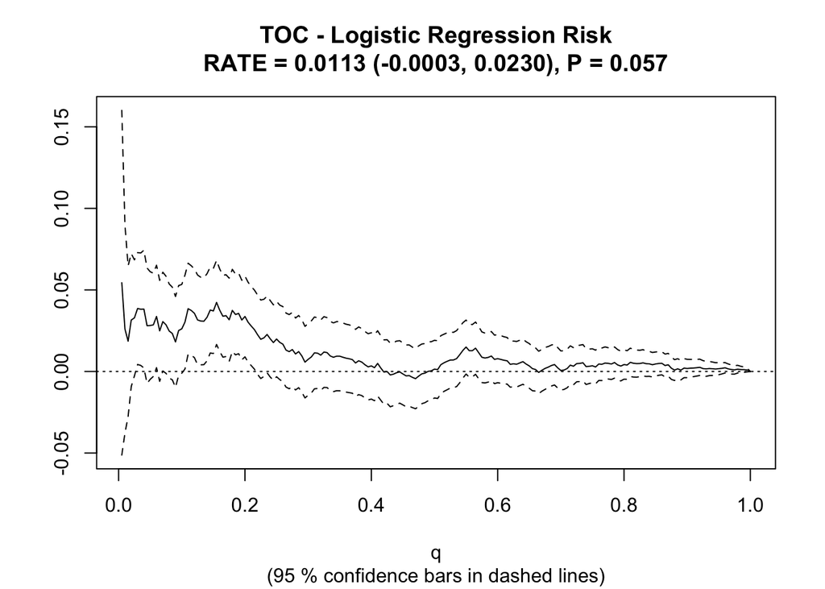

RATE of the Causal Forest

```r
set.seed(SEED)
analyze.RATE(
  eval.model = eval.model.CF,
  priorities = -priorities.on.test$CF,
  title.str = "TOC - Causal Forest\nRATE = %.4f (%.4f, %.4f), P = %.3f",
  target = "AUTOC"
)
```

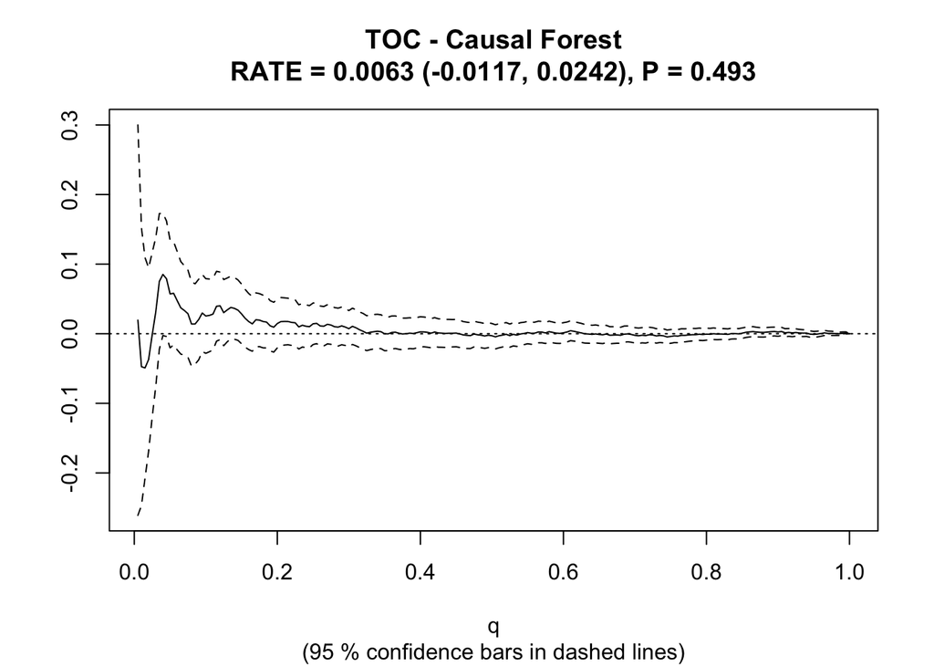

RATE of the Logistic Regression T-Learner

```r
set.seed(SEED)
analyze.RATE(
  eval.model = eval.model.CF,
  priorities = priorities.on.test$GLMTLearner,
  title.str = "TOC - Logistic Regression T-Learner\nRATE = %.4f (%.4f, %.4f), P = %.3f",
  target = "AUTOC"
)
```

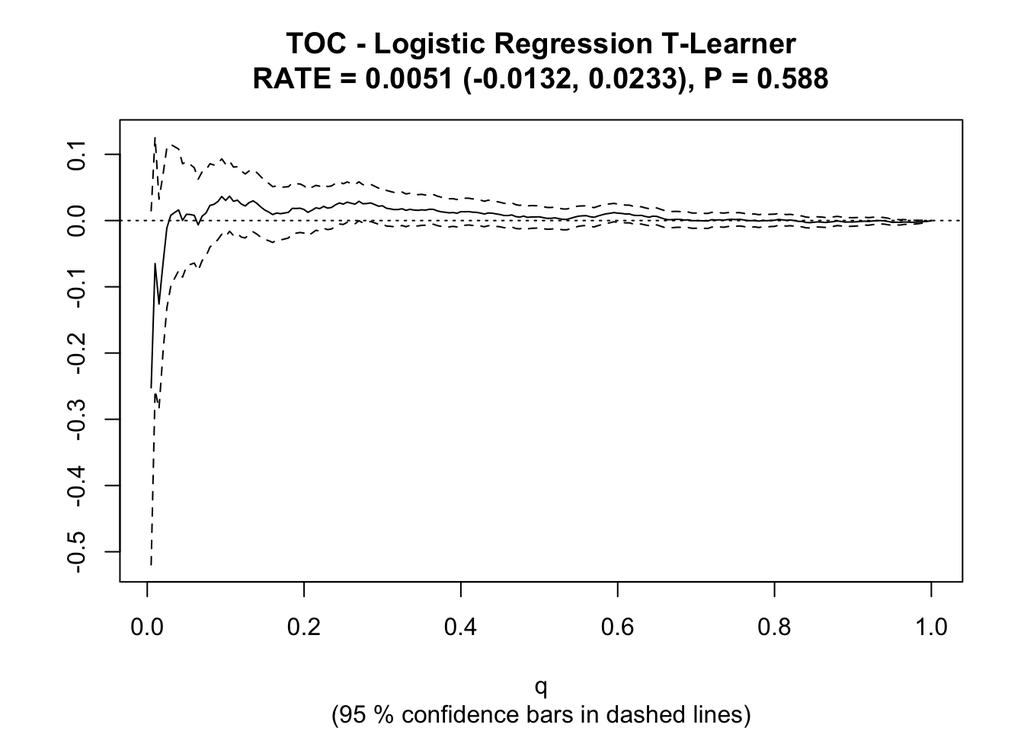

# Comparison to Alternative Approaches for Testing HTEs

## Linear Model with Interaction Terms

We compare our results to those obtained by [Kent et al. 2016](https://doi.org/10.1093/ije/dyw118) on the IST (using a traditional linear modeling approach with a treatment $\times$ risk interaction term).

```r
# Testing for HTEs on the absolute risk difference scale:
# interaction.model <- lm(
#   outcome ~ risk * treatment,
#   data=data.frame(
#     outcome=Y.test,
#     # risk = test.preds.0,  # Could also use the linear model risk
#     risk=priorities.on.test$RFRisk,
#     treatment=W.test
#   )
# )

# Testing for HTEs on the proportional scale
interaction.model <- glm(
  outcome ~ risk * treatment,
  data=data.frame(
    outcome=Y.test,
    risk=priorities.on.test$RFRisk,  # Could also use the linear model risk
    treatment=W.test
  ),
  family="binomial"
)
lmtest::coeftest(
  interaction.model,
  vcov=sandwich::vcovHC(interaction.model, type="HC2")
)
```

```
##
## z test of coefficients:
##
##                Estimate Std. Error  z value Pr(>|z|)
## (Intercept)    -3.10456    0.11917 -26.0512  < 2e-16 ***
## risk            5.95876    0.19220  31.0024  < 2e-16 ***
## treatment      -0.30969    0.17219  -1.7985  0.07209 .
## risk:treatment  0.29986    0.27499   1.0904  0.27553
## ---
## Signif. codes:  0 '***' 0.001 '**' 0.01 '*' 0.05 '.' 0.1 ' ' 1
```

## CATE by Risk Quintile

Taking a common but heuristic approach to understanding treatment effect heterogeneity captured by our random forest model, we calculate the ATE within each quintile of Random Forest Risk scores on the test set.

```r
# Rank observations by the predicted risk under the random forest model
num.rankings <- 5
priorities <- priorities.on.test$RFRisk  # TODO: Extract as a numeric vector
priorities.quantiles <- quantile(priorities, probs = seq(0, 1, by=1/num.rankings))
ranking <- cut(priorities, priorities.quantiles, include.lowest=TRUE, labels=seq(num.rankings))

ols <- lm(aipw.scores ~ 0 + factor(ranking))
forest.ate <- data.frame("aipw", paste0("Q", seq(num.rankings)), lmtest::coeftest(ols, vcov=sandwich::vcovHC(ols, "HC2"))[,1:2])
colnames(forest.ate) <- c("method", "ranking", "estimate", "std.err")
rownames(forest.ate) <- NULL # just for display
forest.ate
```

```
##   method ranking     estimate    std.err
## 1   aipw      Q1 -0.044896054 0.02055790
## 2   aipw      Q2 -0.023276426 0.02240996
## 3   aipw      Q3 -0.013353259 0.02171577
## 4   aipw      Q4 -0.028587197 0.01872058
## 5   aipw      Q5  0.002547041 0.01138887
```

We can view the same results visually:

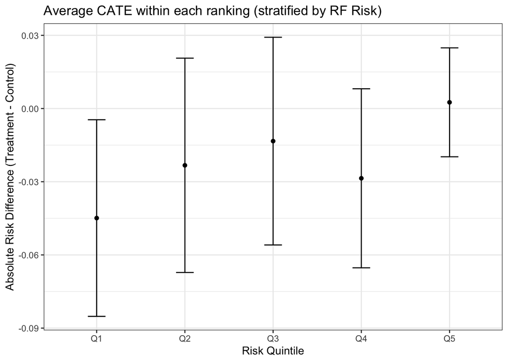

```r
res <- forest.ate

ggplot(res) +
  aes(x = ranking, y = estimate) + #, group=method, color=method) +
  geom_point(position=position_dodge(0.2)) +
  geom_errorbar(
    aes(ymin=estimate-1.96*std.err, ymax=estimate+1.96*std.err),
    width=.2, position=position_dodge(0.2)
  ) +
  ylab("Absolute Risk Difference (Treatment - Control)") + xlab("Risk Quintile") +
  ggtitle("Average CATE within each ranking (stratified by RF Risk)") +
  theme_bw() +
  theme(legend.position="bottom", legend.title = element_blank())
```

```r
ggsave("~/Downloads/CATE_by_risk_quintile.png", device="png", dpi=300)
```

Is there a significant difference between the highest- and lowest-risk quintiles?

```r
t.test(aipw.scores[ranking == 1], aipw.scores[ranking == 5])
```

```
##
##  Welch Two Sample t-test
##
## data:  aipw.scores[ranking == 1] and aipw.scores[ranking == 5]
## t = -2.0187, df = 2958, p-value = 0.04361
## alternative hypothesis: true difference in means is not equal to 0
## 95 percent confidence interval:
##  -0.09352460 -0.00136159
## sample estimates:
##    mean of x    mean of y
## -0.044896054  0.002547041
```

# Epilogue: How you can fool yourself into a false positive result

If you do the trick of comparing the group predicted to benefit against the group predicted to be harmed on the same split you used for training the base models, you will likely obtain a result suggesting heterogeneity…

```r
# Estimate Y(1) for every subject in the test set
train.preds.1 <- predict(train.model.TLearner.treated, train.df, "response")

# Estimate Y(0) for every subject in the test set
train.preds.0 <- predict(train.model.TLearner.controls, train.df, "response")

# Estimate Y(1) - Y(0) for every subject in the test set
train.ite.est <- train.preds.1 - train.preds.0

print("Estimated ATE amongst individuals expected to benefit (train set)")
```

```
## [1] "Estimated ATE amongst individuals expected to benefit (train set)"
```

```r
print(
  mean(Y.train[(W.train == 1) & (train.ite.est <= 0)]) -
  mean(Y.train[(W.train == 0) & (train.ite.est <= 0)])
)
```

```
## [1] -0.04822271
```

```r
print("Estimated ATE amongst individuals _not_ expected to benefit (train set)")
```

```
## [1] "Estimated ATE amongst individuals _not_ expected to benefit (train set)"
```

```r
print(
  mean(Y.train[(W.train == 1) & (train.ite.est > 0)]) -
  mean(Y.train[(W.train == 0) & (train.ite.est > 0)])
)
```

```
## [1] 0.03018454
```

But what happens when we run the same procedure on the test set? (eg, without succumbing to overfitting)

```r
test.ite.est <- priorities.on.test$GLMTLearner
print("Estimated ATE amongst individuals expected to benefit (test set)")
```

```
## [1] "Estimated ATE amongst individuals expected to benefit (test set)"
```

```r
print(
  mean(Y.test[(W.test == 1) & (test.ite.est <= 0)]) -
  mean(Y.test[(W.test == 0) & (test.ite.est <= 0)])
)
```

```
## [1] -0.02793066
```

```r
print("Estimated ATE amongst individuals _not_ expected to benefit (test set)")
```

```
## [1] "Estimated ATE amongst individuals _not_ expected to benefit (test set)"
```

```r
print(
  mean(Y.test[(W.test == 1) & (test.ite.est > 0)]) -
  mean(Y.test[(W.test == 0) & (test.ite.est > 0)])
)
```

```
## [1] -0.01186383
```

Oh no! Looks like whatever treatment effect heterogeneity we saw in the train set attenuated substantially when we evaluated on the test set.

Let’s be a bit more rigorous about evaluating the ATE in each stratum using AIPW scores.

What is the estimated ATE for individuals expected to benefit ($\widehat{ITE} \leq 0$)?

```r
ate.est.pred.benefit <- mean(aipw.scores[test.ite.est <= 0])
ate.se.pred.benefit <- sd(aipw.scores[test.ite.est <= 0]) / sqrt(sum(test.ite.est <= 0))
ate.tstat.pred.benefit <- ate.est.pred.benefit / ate.se.pred.benefit
ate.pred.benefit.results <- c(
  estimate = ate.est.pred.benefit,
  std.error = ate.se.pred.benefit,
  t.stat = ate.tstat.pred.benefit,
  pvalue = 2 * pnorm(-abs(ate.tstat.pred.benefit))
)
print(ate.pred.benefit.results)
```

```
##    estimate   std.error      t.stat      pvalue
## -0.03011806  0.01183790 -2.54420609  0.01095264
```

What is the estimated ATE for individuals *not* expected to benefit ($\widehat{ITE} > 0$)?

```r
ate.est.pred.harm <- mean(aipw.scores[test.ite.est > 0])
ate.se.pred.harm <- sd(aipw.scores[test.ite.est > 0]) / sqrt(sum(test.ite.est > 0))
ate.tstat.pred.harm <- ate.est.pred.harm / ate.se.pred.harm
ate.pred.harm.results <- c(
  estimate=ate.est.pred.harm,
  std.error=ate.se.pred.harm,
  t.stat = ate.tstat.pred.harm,
  pvalue = 2 * pnorm(-abs(ate.tstat.pred.harm))
)
print(ate.pred.harm.results)
```

```
##    estimate   std.error      t.stat      pvalue
## -0.01072793  0.01268714 -0.84557522  0.39778975
```

We can also specifically test whether or not there’s a difference in treatment effect between the two strata. Here, the answer is no… (at least not at level alpha=0.05)

```r
t.test(aipw.scores[test.ite.est <= 0], aipw.scores[test.ite.est > 0])
```

```
##
##  Welch Two Sample t-test
##
## data:  aipw.scores[test.ite.est <= 0] and aipw.scores[test.ite.est > 0]
## t = -1.1174, df = 9171.5, p-value = 0.2638
## alternative hypothesis: true difference in means is not equal to 0
## 95 percent confidence interval:
##  -0.05340434  0.01462407
## sample estimates:
##   mean of x   mean of y
## -0.03011806 -0.01072793
```